# Social Reward Reaction Time Modeling

## Set Up

```python
import os
import glob
import pandas as pd
import numpy as np

import matplotlib.pyplot as plt
import seaborn as sns
```

### Set paths

```python
proj_dir = '/Users/hpopal/Google Drive/My Drive/dscn_lab/projects/social_reward/'
data_dir = os.path.join(proj_dir, 'derivatives', 'task_socialreward', 'data')

os.chdir(proj_dir)
```

### Find participants

```python
# Import participant id data
subj_df = pd.read_csv(proj_dir+'participants.tsv', sep='\t')

# Fix participant IDs to match the directories in the data folder (e.g. sub-SCN101 -> SCN_101)
subj_df['participant_id'] = [x[4:7]+'_'+x[7:] for x in subj_df['participant_id']]

print('Found '+str(len(subj_df))+' participants')
```

```
Found 85 participants
```

# Data Cleaning

```python
rt_data = pd.DataFrame(columns=['ParticipantID','Run','ConditionName','Correct_RT'])

# Import data
for subj in subj_df['participant_id']:
    # Find data for all runs
    run_files = glob.glob(os.path.join(data_dir,subj,'*-errors.csv'))

    #temp_subj_df = pd.DataFrame(columns=['ParticpantID','Run','ConditionName','Correct_RT'])
    # Loop through runs and combine into one df
    for run_file in run_files:
        temp_run_data = pd.read_csv(run_file)
        if temp_run_data['redcap_v_task'].sum() > 0:
            continue
        else:
            temp_run_data_fltr = temp_run_data[rt_data.columns]
            rt_data = pd.concat([rt_data, temp_run_data_fltr], ignore_index=True)
```

```python
# Add group info to rt data
rt_data = pd.merge(left=subj_df, right=rt_data,
                   left_on='participant_id', right_on='ParticipantID')
rt_data = rt_data.drop('ParticipantID', axis=1)
```

```python
# Create column for peer info
rt_data['Peer'] = [x.split('_')[1] for x in rt_data['ConditionName']]

# Make group data nominal
rt_data['group'] = rt_data['group'].astype(str)

rt_data
```

|  | participant_id | group | Run | ConditionName | Correct_RT | Peer |
| --- | --- | --- | --- | --- | --- | --- |
| 0 | SCN_101 | 1 | 2 | HighReward_DisPeer | 0.735915 | DisPeer |
| 1 | SCN_101 | 1 | 2 | LowReward_Computer | 0.897369 | Computer |
| 2 | SCN_101 | 1 | 2 | HighReward_SimPeer | 1.268269 | SimPeer |
| 3 | SCN_101 | 1 | 2 | HighReward_Computer | 0.775542 | Computer |
| 4 | SCN_101 | 1 | 2 | HighReward_Computer | 1.093963 | Computer |
| ... | ... | ... | ... | ... | ... | ... |
| 6137 | SCN_234 | 1 | 3 | HighReward_DisPeer | 0.428082 | DisPeer |
| 6138 | SCN_234 | 1 | 3 | HighReward_SimPeer | 0.494318 | SimPeer |
| 6139 | SCN_234 | 1 | 3 | HighReward_SimPeer | 0.359078 | SimPeer |
| 6140 | SCN_234 | 1 | 3 | HighReward_DisPeer | 0.473353 | DisPeer |
| 6141 | SCN_234 | 1 | 3 | LowReward_DisPeer | 0.370476 | DisPeer |

6142 rows × 6 columns

```python
# Create columns to identify conditions
#for cond in ['SimPeer', 'DisPeer', 'Computer']:
#    rt_data[cond] = 0
#    rt_data.loc[rt_data['ConditionName'].str.contains(cond), cond] = 1

#rt_data
```

# Group Results

```python
import statsmodels.api as sm
from statsmodels.formula.api import ols
```

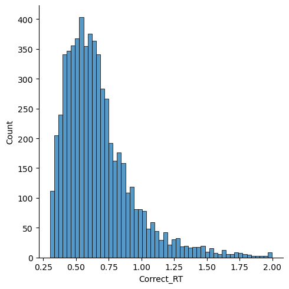

```python
sns.displot(data=rt_data, x='Correct_RT')
```

## Peer Category and Reaction Time

Does the type of peer predict reaction time for all participants (TD and ASD grouped together)?

```python
rt_lm = ols('Correct_RT ~ C(Peer)', data=rt_data).fit() #Specify C for Categorical
print(sm.stats.anova_lm(rt_lm, typ=2))
```

```
              sum_sq      df         F    PR(>F)
C(Peer)     0.083005     2.0  0.576417  0.561939
Residual  435.029772  6042.0       NaN       NaN
```

**Results:** No

## Run and Reaction Time

```python
rt_lm = ols('Correct_RT ~ C(Run)', data=rt_data).fit()
print(sm.stats.anova_lm(rt_lm, typ=2))
```

```
              sum_sq      df         F    PR(>F)
C(Run)      1.987536     3.0  9.240366  0.000004
Residual  433.125241  6041.0       NaN       NaN
```

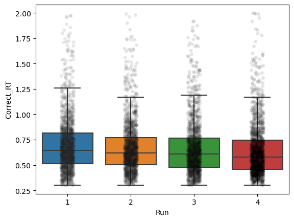

```python
#f, axes = plt.subplots(2, 1, figsize=(7, 7), sharex=False)
sns.despine(left=True)
sns.stripplot(x='Run', y='Correct_RT', data=rt_data, hue='Run',
              palette='dark:black', alpha=.1, jitter=True, legend=False)
#axes[0].legend_.remove()
sns.boxplot(x='Run', y='Correct_RT', data=rt_data, showfliers=False)

#plt.legend(bbox_to_anchor=(1, 1), loc=2, borderaxespad=0.0)
```

## Peer Category, Run, and Reaction Time

Is the type of peer predictive of reaction time over runs?

```python
rt_lm = ols('Correct_RT ~ C(Peer) * C(Run)', data=rt_data).fit()  # Specify C for Categorical
print(sm.stats.anova_lm(rt_lm, typ=2))
```

```
                    sum_sq      df         F    PR(>F)
C(Peer)           0.082343     2.0  0.573915  0.563347
C(Run)            1.986874     3.0  9.232053  0.000004
C(Peer):C(Run)    0.245956     6.0  0.571421  0.753432
Residual        432.796941  6033.0       NaN       NaN
```

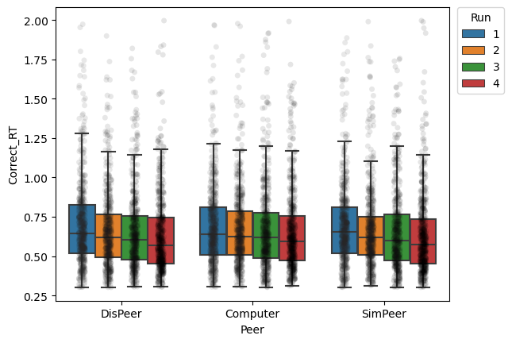

```python
ax = sns.boxplot(x='Peer', y='Correct_RT', hue='Run', data=rt_data, showfliers=False)

sns.stripplot(x='Peer', y='Correct_RT', hue='Run', data=rt_data,
              palette='dark:black', alpha=.1, legend=False, ax=ax, dodge=True)
plt.legend(bbox_to_anchor=(1.02, 1), title='Run', loc='upper left', borderaxespad=0)
```

**Results:** Overall, there were quicker reaction times in subsequent runs, but there was no interaction with the type of peer.

## Log Reaction Time

```python
rt_data['Correct_RT_log'] = np.log(rt_data['Correct_RT'])
```

```python
ax[1]
```

[output not shown]

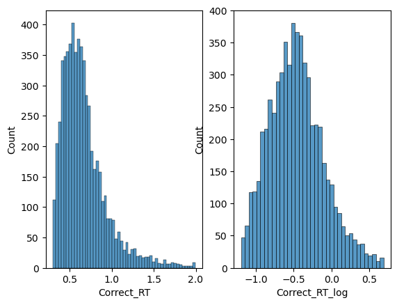

```python
fig, axes = plt.subplots(1, 2)
sns.histplot(data=rt_data, x='Correct_RT', ax=axes[0])
sns.histplot(data=rt_data, x='Correct_RT_log', ax=axes[1])
```

```python
rt_lm = ols('Correct_RT_log ~ C(Peer) * Run', data=rt_data).fit()  # Specify C for Categorical
print(sm.stats.anova_lm(rt_lm, typ=2))
```

```
                 sum_sq      df          F        PR(>F)
C(Peer)        0.230364     2.0   0.906623  4.039410e-01
Run            5.094330     3.0  13.366201  1.081625e-08
C(Peer):Run    0.490239     6.0   0.643130  6.957739e-01
Residual     766.462874  6033.0        NaN           NaN
```

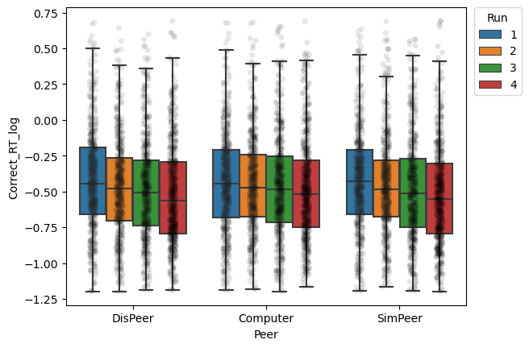

```python
ax = sns.boxplot(rt_data, x='Peer', y='Correct_RT_log', hue='Run', showfliers=False)

sns.stripplot(rt_data, x='Peer', y='Correct_RT_log', hue='Run',
              palette='dark:black', alpha=.1, legend=False, ax=ax, dodge=True)
plt.legend(bbox_to_anchor=(1.02, 1), title='Run', loc='upper left', borderaxespad=0)
```

**Results:** Again, no interaction between the type of peer and runs in predicting log reaction time.

# Between Group Analysis

## TD Group

**Question:** Will the type of peer and run number be predictive of reaction time?

```python
rt_data_tyd = rt_data[rt_data['group'] == 1]
rt_data_tyd
```

[output not shown]

4079 rows × 8 columns

```python
rt_lm = ols('Correct_RT_log ~ C(Peer) * Run', data=rt_data_tyd).fit()  # Specify C for Categorical
print(sm.stats.anova_lm(rt_lm, typ=2))
```

```
                 sum_sq      df          F        PR(>F)
C(Peer)        0.361781     2.0   1.465029  2.311952e-01
Run            5.481875     3.0  14.799189  1.396520e-09
C(Peer):Run    0.867295     6.0   1.170699  3.188592e-01
Residual     494.136634  4002.0        NaN           NaN
```

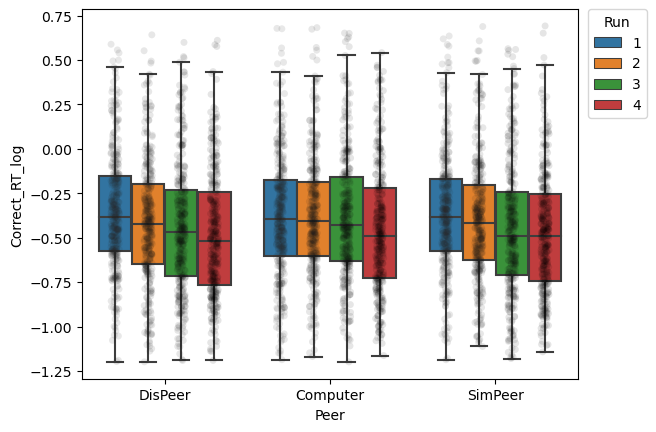

```python
ax = sns.boxplot(rt_data_tyd, x='Peer', y='Correct_RT_log', hue='Run', showfliers=False)

sns.stripplot(rt_data_tyd, x='Peer', y='Correct_RT_log', hue='Run',
              palette='dark:black', alpha=.1, legend=False, ax=ax, dodge=True)
plt.legend(bbox_to_anchor=(1.02, 1), title='Run', loc='upper left', borderaxespad=0)
```

**Results:** Just as in the entire sample, TD participants were faster as the task progressed, but showed no interaction between run number and the type of peer in predicting log reaction time.

## ASD Group

```python
rt_data_asd = rt_data[rt_data['group'] == 2]
rt_data_asd
```

[output not shown]

2063 rows × 8 columns

```python
rt_lm = ols('Correct_RT_log ~ C(Peer) * Run', data=rt_data_asd).fit()  # Specify C for Categorical
print(sm.stats.anova_lm(rt_lm, typ=2))
```

```
                 sum_sq      df         F    PR(>F)
C(Peer)        0.000157     2.0  0.000668  0.999332
Run            0.847675     3.0  2.399485  0.066158
C(Peer):Run    0.752343     6.0  1.064816  0.381458
Residual     237.753258  2019.0       NaN       NaN
```

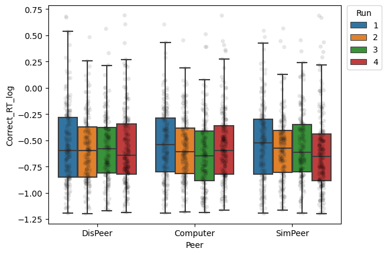

```python
ax = sns.boxplot(rt_data_asd, x='Peer', y='Correct_RT_log', hue='Run', showfliers=False)

sns.stripplot(rt_data_asd, x='Peer', y='Correct_RT_log', hue='Run',
              palette='dark:black', alpha=.1, legend=False, ax=ax, dodge=True)
plt.legend(bbox_to_anchor=(1.02, 1), title='Run', loc='upper left', borderaxespad=0)
```

**Results:** In the ASD group, there was no relationship between the type of peer, run number, and log reaction times. ASD participants seem to be responding similarily throughout the task for all conditions and all runs.

## TD vs ASD

Finally, we well test for group differences.

```python
rt_data['group'].astype('str') + '_' + rt_data['Run'].astype('str')
```

```
0       1_2
1       1_2
2       1_2
3       1_2
4       1_2
       ...
6137    1_3
6138    1_3
6139    1_3
6140    1_3
6141    1_3
Length: 6142, dtype: object
```

```python
# Create new variable to capture run and group for the hue in the bar plot
rt_data['Run_group'] = rt_data['Run'].astype('str') + '_' + rt_data['group'].astype('str')
```

```python
sns.color_palette('tab10', 4)
```

```python
sns.color_palette('pastel', 4)
```

```python
palette_a = sns.color_palette('tab10', 4).as_hex()
palette_b = sns.color_palette('pastel', 4).as_hex()

palette_c = [None]*(len(palette_a)+len(palette_b))
palette_c[::2] = palette_a
palette_c[1::2] = palette_b
palette_c
```

```
['#1f77b4',
 '#a1c9f4',
 '#ff7f0e',
 '#ffb482',
 '#2ca02c',
 '#8de5a1',
 '#d62728',
 '#ff9f9b']
```

```python
rt_lm = ols('Correct_RT_log ~ C(Peer) * Run * group', data=rt_data).fit()  # Specify C for Categorical
print(sm.stats.anova_lm(rt_lm, typ=2))
```

```
                       sum_sq      df           F        PR(>F)
C(Peer)              0.236293     2.0    0.971950  3.784039e-01
Run                  5.328344     3.0   14.611468  1.765525e-09
group               32.314861     1.0  265.842963  1.615831e-58
C(Peer):Run          0.486576     6.0    0.667148  6.762858e-01
C(Peer):group        0.118509     2.0    0.487466  6.142050e-01
Run:group            1.004542     3.0    2.754671  4.095089e-02
C(Peer):Run:group    1.133062     6.0    1.553550  1.565098e-01
Residual           731.889893  6021.0         NaN           NaN
```

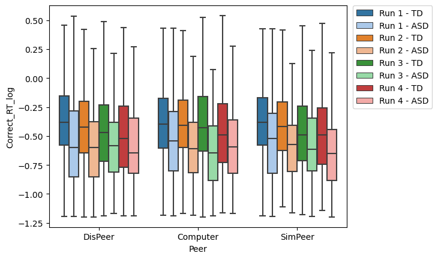

```python
ax = sns.boxplot(rt_data, x='Peer', y='Correct_RT_log', hue='Run_group', showfliers=False,
                hue_order = ['1_1', '1_2', '2_1', '2_2',
                         '3_1', '3_2', '4_1', '4_2'],
            palette=palette_c)


handler, label = ax.get_legend_handles_labels()
ax.legend(handler, ['Run 1 - TD', 'Run 1 - ASD', 'Run 2 - TD', 'Run 2 - ASD',
                   'Run 3 - TD', 'Run 3 - ASD', 'Run 4 - TD', 'Run 4 - ASD'],
          bbox_to_anchor=(1.02, 1), loc='upper left', borderaxespad=0,
           fontsize=10)
```

**Figure note:** Bolder colors = TD, pastel colors = ASD

**Results:** There was an overall main effect for runs, such that across all participants, reaction times were faster through the course of the task. There was also a group main effect, such that the autistic adolescents had faster reaction times than the typically developing adolescents. Finally, there was an interaction between run and group, such that typically developing adolescents had quicker reaction times as the task progressed, whereas autistic adolescents did not.